# HW6_XianjieQue

XianjieQue

2025-03-16

## 12.1

### 12.1 (a) Prove (12.18)

12.18 is:

$$\frac{1}{|C_k|}\sum_{i,i' \in C_k} \sum_{j=1}^p (x_{ij} -
x_{i'j})^2 =
2 \sum_{i \in C_k} \sum_{j=1}^p (x_{ij} - \bar{x}_{kj})^2$$

where
$$\bar{x}_{kj} =
\frac{1}{|C_k|}\sum_{i \in C_k} x_{ij}$$

For any two observations in cluster, we rewrite their difference:

$$\begin{align}
(x_{ij} - x_{i'j})^2
= & ((x_{ij} - \bar{x}_{kj}) - (x_{i'j} - \bar{x}_{kj}))^2 \\
= & (x_{ij} - \bar{x}_{kj})^2 -
2(x_{ij} - \bar{x}_{kj})(x_{i'j} - \bar{x}_{kj}) +
(x_{i'j} - \bar{x}_{kj})^2
\end{align}$$

Note that the first term is independent of $i'$ and the last is independent of $i$.

Therefore, it can be written as:

$$= \frac{1}{|C_k|} \sum_{i,i' \in C_k} \sum_{j=1}^p (x_{ij} -
\bar{x}_{kj})^2 -
\frac{2}{|C_k|} \sum_{i,i' \in C_k} \sum_{j=1}^p (x_{ij} -
\bar{x}_{kj})(x_{i'j} - \bar{x}_{kj}) +
\frac{1}{|C_k|} \sum_{i,i' \in C_k} \sum_{j=1}^p (x_{i'j} -
\bar{x}_{kj})^2$$

Since the middle term sums to zero:

$$\sum_{i \in C_k} (x_{ij} - \bar{x}_{kj}) = 0,$$

we obtain:

$$2 \sum_{i \in C_k} \sum_{j=1}^p (x_{ij} - \bar{x}_{kj})^2$$

It proves equation (12.18).

### 12.1 (b) argue that the K-means clustering algorithm (Algorithm 12.2) decreases the objective (12.17) at each iteration.

Equation (12.18) shows that the sum of squared Euclidean distances between all possible pairs of points in a cluster can be rewritten in terms of the variance within the cluster. The K-means algorithm minimizes the sum of squared Euclidean distances between points and their cluster centroids, effectively reducing the within-cluster variance at each step.

Since the K-means algorithm updates cluster centroids by minimizing the squared distance to all points assigned to them, the objective function decreases with each iteration until convergence.

## 12.2 hierarchical clustering

### 12.2 (a) Complete Linkage Clustering

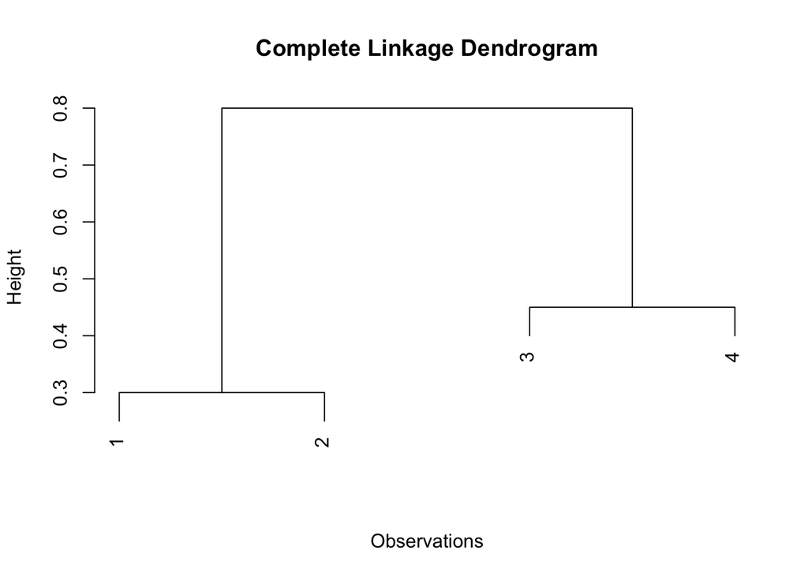

```r
library(cluster)

dist_matrix <- matrix(c(
  0,   0.3, 0.4, 0.7,
  0.3, 0,   0.5, 0.8,
  0.4, 0.5, 0,   0.45,
  0.7, 0.8, 0.45, 0
), nrow = 4, byrow = TRUE)

# Convert to distance object
dist_obj <- as.dist(dist_matrix)

# Complete Linkage Clustering
hc_complete <- hclust(dist_obj, method = "complete")

# Plot dendrogram
plot(hc_complete, main = "Complete Linkage Dendrogram", sub = "", xlab = "Observations", ylab = "Height")
```

### 12.2 (b) Single Linkage Clustering

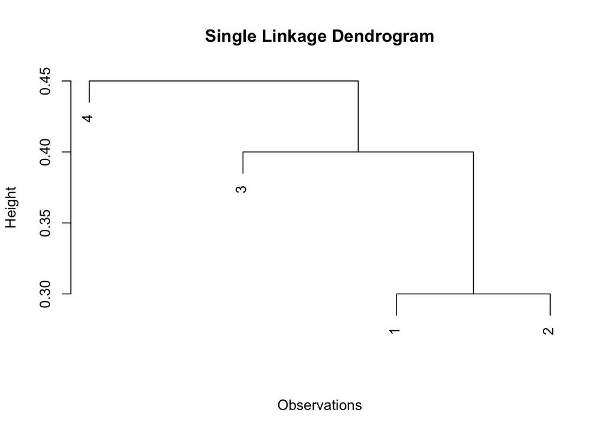

```r
hc_single <- hclust(dist_obj, method = "single")
plot(hc_single, main = "Single Linkage Dendrogram", sub = "", xlab = "Observations", ylab = "Height")
```

### 12.2 (c) Cutting Complete into 2

Cluster 1: (1,2) Cluster 2: (3,4)

```r
cut_complete <- cutree(hc_complete, 2)
table(1:4, cut_complete)
```

```
##    cut_complete
##     1 2
##   1 1 0
##   2 1 0
##   3 0 1
##   4 0 1
```

### 12.2 (d) Cutting Single into 2

Cluster 1: (1,2,3) Cluster 2: (4)

```r
cut_single <- cutree(hc_single, 2)
table(1:4, cut_single)
```

```
##    cut_single
##     1 2
##   1 1 0
##   2 1 0
##   3 1 0
##   4 0 1
```

### 12.2 (e) reposition

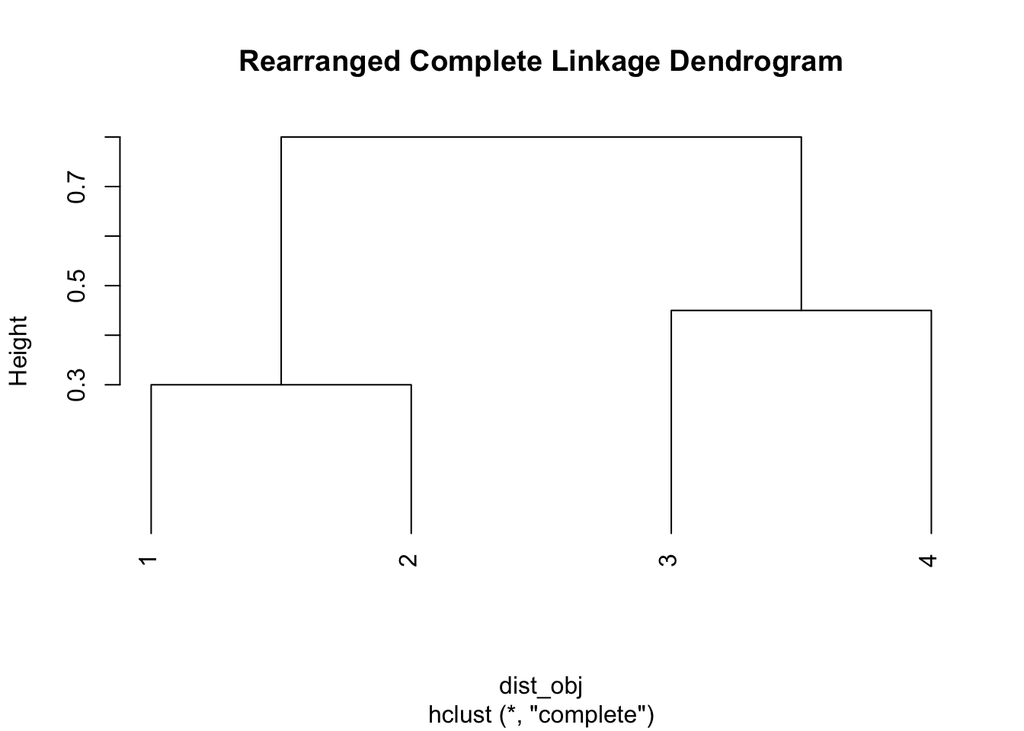

```r
plot(hc_complete, hang = -1, main = "Rearranged Complete Linkage Dendrogram")
```

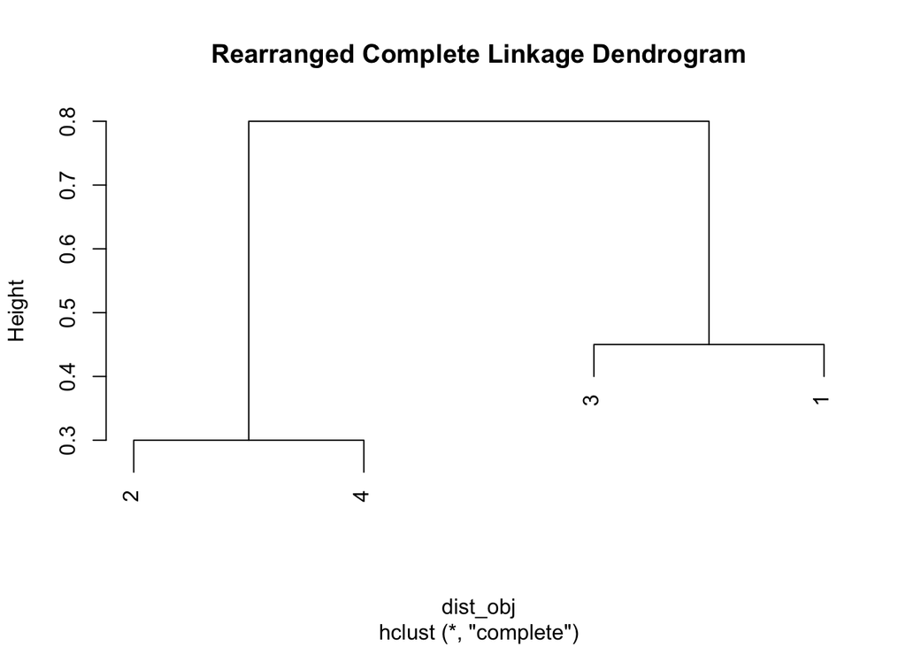

```r
# we can also change the label
plot(hc_complete, labels = c(2,4,3,1), main = "Rearranged Complete Linkage Dendrogram")
```

## 12.8 calculate PVE in two ways

I used centered and scaled variables for both methods.

### 12.8 (a) Using the sdev output

```r
data("USArrests")
# dim(USArrests)

pca_result <- prcomp(USArrests, center = TRUE, scale = TRUE)

pve_sdev <- pca_result$sdev^2 / sum(pca_result$sdev^2)

pve_sdev
```

```
## [1] 0.62006039 0.24744129 0.08914080 0.04335752
```

### 12.8 (b) Using Equation 12.10

From the result, we can see that these two approaches give the same results.

```r
pve_manual <- colSums(pca_result$x^2) / sum(colSums(scale(USArrests)^2))

pve_manual
```

```
##        PC1        PC2        PC3        PC4
## 0.62006039 0.24744129 0.08914080 0.04335752
```

## 12.10 perform PCA and K-means on simulated data

### 12.10 (a) generate dataset

```r
set.seed(6)
data_A <- matrix(rnorm(20 * 50), ncol = 50)
data_B <- matrix(rnorm(20 * 50), ncol = 50) + 5
data_C <- matrix(rnorm(20 * 50), ncol = 50) - 8

data10 <- rbind(data_A, data_B, data_C)

classes <- rep(c("A", "B", "C"), each = 20)
dimnames(data10) <- list(classes, paste0("V", 1:50))
```

### 12.10 (b) Perform PCA and plot the first 2 PCs

We can see there are 3 separated clusters.

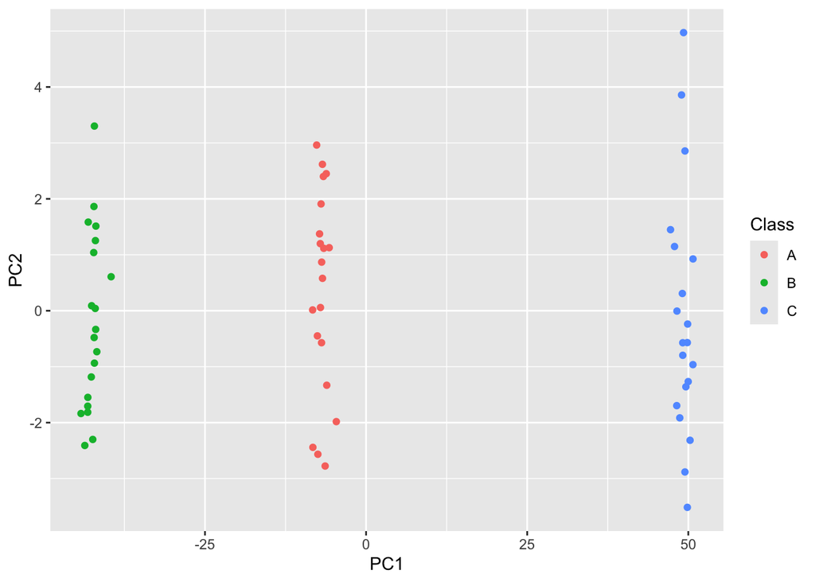

```r
set.seed(6)
pca10 <- prcomp(data10)

library(ggplot2)
ggplot(
  data.frame(Class = classes, PC1 = pca10$x[, 1], PC2 = pca10$x[, 2]),
  aes(x = PC1, y = PC2, col = Class)
) +
  geom_point()
```

### 12.10 (c) Perform K-means clustering with K = 3.

“K-means clustering with K = 3” doesn’t perform well from the result.

There are 3 clusters. Cluster 2 is a mix of Class A and B. However, Class C was split into two clusters.

```r
set.seed(6)
km_10_3 <- kmeans(data10, 3)
km_10_3$cluster
```

```
## A A A A A A A A A A A A A A A A A A A A B B B B B B B B B B B B B B B B B B B B
## 2 2 2 2 2 2 2 2 2 2 2 2 2 2 2 2 2 2 2 2 2 2 2 2 2 2 2 2 2 2 2 2 2 2 2 2 2 2 2 2
## C C C C C C C C C C C C C C C C C C C C
## 1 3 3 3 1 1 1 1 1 1 3 3 1 1 1 1 3 1 1 1
```

```r
table(km_10_3$cluster, names(km_10_3$cluster))
```

```
##
##      A  B  C
##   1  0  0 14
##   2 20 20  0
##   3  0  0  6
```

### 12.10 (d) Perform K-means clustering with K = 2.

K-means clustering with K = 2 effectively defines cluster 1 to be class C, but cluster 2 is a mix of classes A and B.

The reason may be the difference of the mean of classes A and B is smaller.

```r
set.seed(6)
km_10_2 <- kmeans(data10, 2)
km_10_2$cluster
```

```
## A A A A A A A A A A A A A A A A A A A A B B B B B B B B B B B B B B B B B B B B
## 2 2 2 2 2 2 2 2 2 2 2 2 2 2 2 2 2 2 2 2 2 2 2 2 2 2 2 2 2 2 2 2 2 2 2 2 2 2 2 2
## C C C C C C C C C C C C C C C C C C C C
## 1 1 1 1 1 1 1 1 1 1 1 1 1 1 1 1 1 1 1 1
```

```r
table(km_10_2$cluster, names(km_10_2$cluster))
```

```
##
##      A  B  C
##   1  0  0 20
##   2 20 20  0
```

### 12.10 (e) Perform K-means clustering with K = 4.

K-means clustering with K = 4 effectively defines cluster 2 to be class A, cluster 4 to be class B, but clusters 1 and 3 are split over class C.

```r
set.seed(6)
km_10_4 <- kmeans(data10, 4)
km_10_4$cluster
```

```
## A A A A A A A A A A A A A A A A A A A A B B B B B B B B B B B B B B B B B B B B
## 2 2 2 2 2 2 2 2 2 2 2 2 2 2 2 2 2 2 2 2 4 4 4 4 4 4 4 4 4 4 4 4 4 4 4 4 4 4 4 4
## C C C C C C C C C C C C C C C C C C C C
## 1 3 3 3 1 1 1 1 1 1 3 3 1 1 1 1 3 1 1 1
```

```r
table(km_10_4$cluster, names(km_10_4$cluster))
```

```
##
##      A  B  C
##   1  0  0 14
##   2 20  0  0
##   3  0  0  6
##   4  0 20  0
```

### 12.10 (f) Perform K-means clustering with K = 3 on the first 2 PCs

“K = 3 on the first 2 PCs” doesn’t perform well from the result.

There are 3 clusters. Cluster 2 is a mix of Class A and B. However, Class C was split into two clusters.

The result is quite similar to the result of “Perform K-means clustering with K = 3”.

```r
set.seed(6)
km_10_f <- kmeans(pca10$x[, 1:2], 3)
km_10_f$cluster
```

```
## A A A A A A A A A A A A A A A A A A A A B B B B B B B B B B B B B B B B B B B B
## 2 2 2 2 2 2 2 2 2 2 2 2 2 2 2 2 2 2 2 2 2 2 2 2 2 2 2 2 2 2 2 2 2 2 2 2 2 2 2 2
## C C C C C C C C C C C C C C C C C C C C
## 1 3 3 3 1 1 1 1 1 1 3 1 1 1 1 1 3 1 1 1
```

```r
table(km_10_f$cluster, names(km_10_f$cluster))
```

```
##
##      A  B  C
##   1  0  0 15
##   2 20 20  0
##   3  0  0  5
```

### 12.10 (g) Perform K-means clustering with K = 3 + “scale() function”

“K = 3 after scaling” doesn’t perform well from the result.

There are 3 clusters. Cluster 2 is a mix of Class A and B. However, Class C was split into two clusters.

The result is extremely similar to the result of “Perform K-means clustering with K = 3” without scaling.

```r
set.seed(6)
km_10_g <- kmeans(scale(data10), 3)
km_10_g$cluster
```

```
## A A A A A A A A A A A A A A A A A A A A B B B B B B B B B B B B B B B B B B B B
## 2 2 2 2 2 2 2 2 2 2 2 2 2 2 2 2 2 2 2 2 2 2 2 2 2 2 2 2 2 2 2 2 2 2 2 2 2 2 2 2
## C C C C C C C C C C C C C C C C C C C C
## 1 3 3 3 1 1 1 1 1 1 3 3 1 1 1 1 3 1 1 1
```

```r
table(km_10_g$cluster, names(km_10_g$cluster))
```

```
##
##      A  B  C
##   1  0  0 14
##   2 20 20  0
##   3  0  0  6
```

## 12.13 gene expression data set “Ch12Ex13.csv”

### 12.13 (a) Load in the data

```r
data13 <- read.csv("Ch12Ex13.csv", header = FALSE)
dim(data13)
```

```
## [1] 1000   40
```

### 12.13 (b) hierarchical clustering using correlation-based distance

Yes, the genes separate the samples into the two groups. My results depend on the type of linkage used.

For example, in the case of average linkage and single linkage, the disease samples all fall within a subset of the healthy samples. But the dissimilarity is more distinct in complete linkage.

But generally, all three types of linkage clearly distinguish healthy samples from diseased samples.

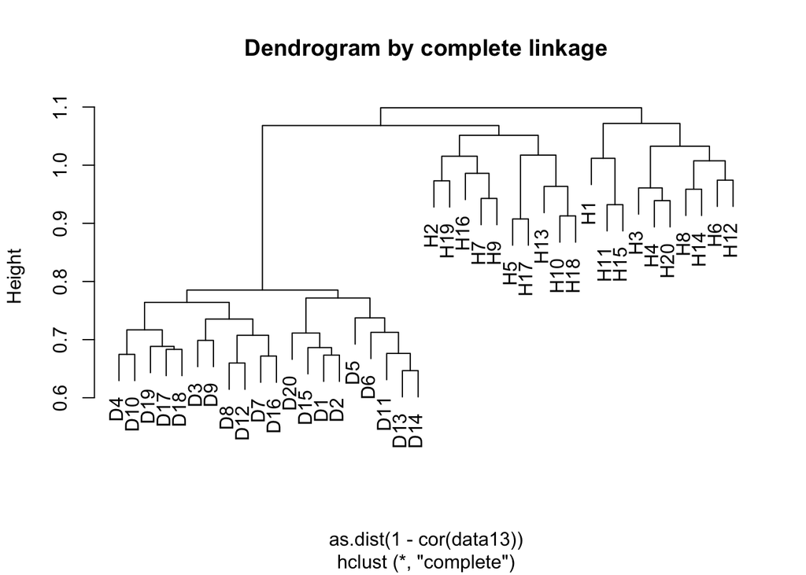

```r
colnames(data13) <- c(paste0("H", 1:20), paste0("D", 1:20))

# complete linkage
hc_complete_13 <- hclust(as.dist(1 - cor(data13)), method = "complete")
plot(hc_complete_13, main = "Dendrogram by complete linkage")
```

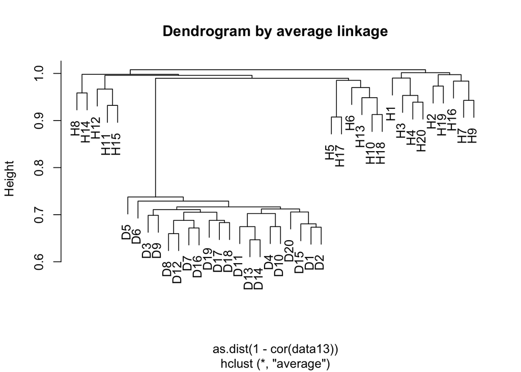

```r
# average linkage
hc_average_13 <- hclust(as.dist(1 - cor(data13)), method = "average")
plot(hc_average_13, main = "Dendrogram by average linkage")
```

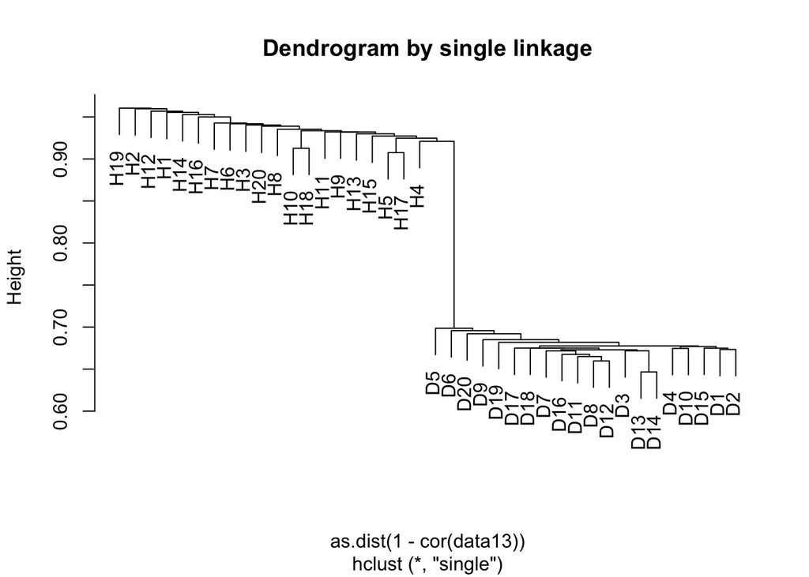

```r
# single linkage
hc_single_13 <- hclust(as.dist(1 - cor(data13)), method = "single")
plot(hc_single_13, main = "Dendrogram by single linkage")
```

### 12.13 (c) select the most significantly differential expressed genes

```r
pvals <- p.adjust(apply(data13, 1, function(gene) t.test(gene[1:20], gene[21:40])$p.value))
which(pvals < 0.05)
```

```
##   [1]  11  12  13  14  15  16  17  18  19  20 501 502 503 504 505 506 507 508
##  [19] 509 511 512 513 514 515 516 517 519 520 521 522 523 524 525 526 527 528
##  [37] 529 530 531 532 533 534 535 536 537 538 539 540 541 542 543 544 545 546
##  [55] 547 548 549 550 551 552 553 554 555 556 557 558 559 560 561 562 563 564
##  [73] 565 566 567 568 569 570 571 572 574 575 576 577 578 579 580 581 582 583
##  [91] 584 586 587 588 589 590 591 592 593 595 596 597 598 599 600
```

```r
# and we can choose the top 10 smallest genes
order(pvals)[1:10]
```

```
##  [1] 502 589 600 590 565 551 593 584 538 569
```

```r
variances <- apply(data13, 1, function(gene) var(gene[1:20]) + var(gene[21:40]))

order(variances, decreasing = TRUE)[1:10]
```

```
##  [1] 320 914 325 529 998 291 306 746 966 150
```

## Conduct PLS on the Credit data, and compare your results to those from the PCR (Figure 6.20 in the textbook).

I performed PLS and PCR on the Credit data seperately.

In PLS, the lowest cross-validation error occurs when M = 3 components are used. The corresponding test set MSE is 24203.98 rmse is 155.5763

After I performed PLS using the full data set, using M = 3, the result is:

```
     1 comps  2 comps  3 comps
```

X 45.46 56.34 66.19

Balance 65.47 82.09 87.81

In PCR, the lowest cross-validation error occurs when M = 5 components are used. The corresponding test set MSE is 24152.44 rmse is 155.4106

```
     1 comps  2 comps  3 comps  4 comps  5 comps
```

Balance 65.47 82.09 87.81 87.82 87.82

The test MSE by PLS is comparable to, but slightly higher than, the test MSE obtained using PCR. It suggests that PCR is performing pretty well despite not considering response information during component selection.

```r
library(ISLR2)
library(pls)
library(caret)
# Remove categorical variables
Credit_numeric <- Credit[, !(names(Credit) %in% c("Own", "Student", "Married", "Region"))]
str(Credit_numeric)
```

```
## 'data.frame':    400 obs. of  7 variables:
##  $ Income   : num  14.9 106 104.6 148.9 55.9 ...
##  $ Limit    : num  3606 6645 7075 9504 4897 ...
##  $ Rating   : num  283 483 514 681 357 569 259 512 266 491 ...
##  $ Cards    : num  2 3 4 3 2 4 2 2 5 3 ...
##  $ Age      : num  34 82 71 36 68 77 37 87 66 41 ...
##  $ Education: num  11 15 11 11 16 10 12 9 13 19 ...
##  $ Balance  : num  333 903 580 964 331 ...
```

```r
# Create train and test sets (60% training, 40% testing)
set.seed(6)
trainIndex <- createDataPartition(Credit_numeric$Balance, p = 0.6, list = FALSE)
trainData <- Credit_numeric[trainIndex, ]
testData <- Credit_numeric[-trainIndex, ]

# Define response and predictor variables
X_train <- trainData[, -ncol(trainData)]
Y_train <- trainData$Balance
X_test <- testData[, -ncol(testData)]
Y_test <- testData$Balance

# PLS
set.seed(6)
pls.fit <- plsr(Balance ~ ., data = trainData,
                scale = T, validation = "CV")
summary(pls.fit)
```

```
## Data:    X dimension: 241 6
##  Y dimension: 241 1
## Fit method: kernelpls
## Number of components considered: 6
##
## VALIDATION: RMSEP
## Cross-validated using 10 random segments.
##        (Intercept)  1 comps  2 comps  3 comps  4 comps  5 comps  6 comps
## CV           465.7    278.7    212.2    169.0    169.2    169.3    171.3
## adjCV        465.7    278.6    211.3    168.7    168.9    168.8    170.9
##
## TRAINING: % variance explained
##          1 comps  2 comps  3 comps  4 comps  5 comps  6 comps
## X          45.34    56.45    65.70    82.35    82.53   100.00
## Balance    64.55    81.24    87.54    87.54    87.58    87.58
```

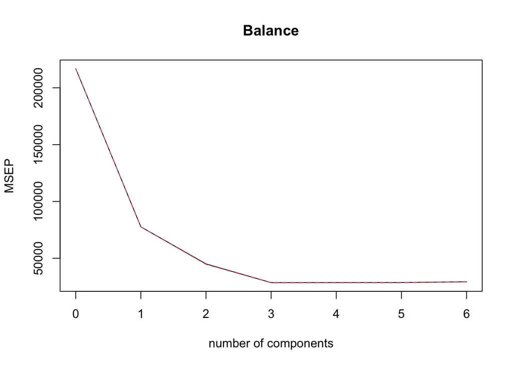

```r
validationplot(pls.fit, val.type = "MSEP")
```

```r
# we can see from the plot and also the result that the lowest cross-validation error occurs when M = 3 components are used

pls.pred <- predict(pls.fit, X_test, ncomp = which.min(pls.fit$validation$PRESS))
mean((pls.pred - Y_test)^2)
```

```
## [1] 24203.98
```

```r
# we can also obtain "rmse" by
sqrt(mean((pls.pred - Y_test)^2))
```

```
## [1] 155.5763
```

```r
# Finally, we perform PLS using the full data set, using M = 3

pls.fit.full <- plsr(Balance ~ ., data = Credit_numeric, scale = TRUE, ncomp = 3)
summary(pls.fit.full)
```

```
## Data:    X dimension: 400 6
##  Y dimension: 400 1
## Fit method: kernelpls
## Number of components considered: 3
## TRAINING: % variance explained
##          1 comps  2 comps  3 comps
## X          45.46    56.34    66.19
## Balance    65.47    82.09    87.81
```

```r
# PCR

set.seed(6)
pcr.fit <- pcr(Balance ~ ., data = trainData,
               scale = T, validation = "CV")
summary(pcr.fit)
```

```
## Data:    X dimension: 241 6
##  Y dimension: 241 1
## Fit method: svdpc
## Number of components considered: 6
##
## VALIDATION: RMSEP
## Cross-validated using 10 random segments.
##        (Intercept)  1 comps  2 comps  3 comps  4 comps  5 comps  6 comps
## CV           465.7    304.4    305.5    307.1    292.8    169.1    171.3
## adjCV        465.7    304.3    305.6    307.8    292.6    168.8    170.9
##
## TRAINING: % variance explained
##          1 comps  2 comps  3 comps  4 comps  5 comps  6 comps
## X          45.78    63.40    80.11    95.70    99.96   100.00
## Balance    57.14    57.14    57.33    61.84    87.54    87.58
```

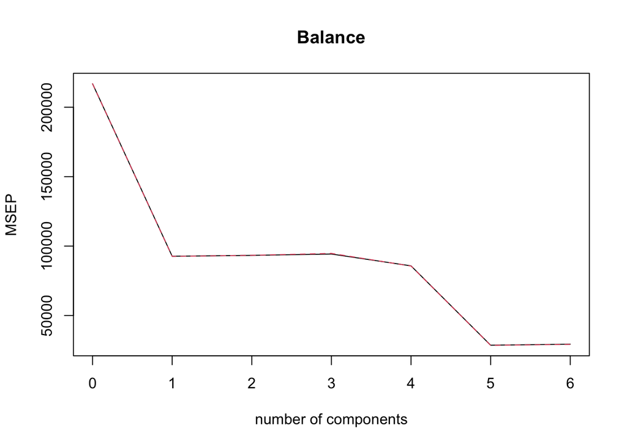

```r
validationplot(pcr.fit, val.type = "MSEP")
```

```r
# we can see from the plot and also the result that the lowest cross-validation error occurs when M = 5 components are used

pcr.pred <- predict(pcr.fit, X_test, ncomp = which.min(pcr.fit$validation$PRESS))
mean((pcr.pred - Y_test)^2)
```

```
## [1] 24152.44
```

```r
# we can also obtain "rmse" by
sqrt(mean((pcr.pred - Y_test)^2))
```

```
## [1] 155.4106
```

```r
# Finally, we perform PCR using the full data set, using M = 5

pcr.fit.full <- plsr(Balance ~ ., data = Credit_numeric, scale = TRUE, ncomp = 5)
summary(pcr.fit.full)
```

```
## Data:    X dimension: 400 6
##  Y dimension: 400 1
## Fit method: kernelpls
## Number of components considered: 5
## TRAINING: % variance explained
##          1 comps  2 comps  3 comps  4 comps  5 comps
## X          45.46    56.34    66.19    82.39    99.94
## Balance    65.47    82.09    87.81    87.82    87.82
```